# Data Visualization with `ggplot2`

This lab focuses on data visualization and how to create high quality graphics using the `ggplot2` package. In this lab we will use cleaned data, with subsequent labs covering how to manipulate data prior to graphing.

This lab will use the `ggplot2` package:

```r
# install.packages("ggplot2")
library(ggplot2)
```

It will also use data from The College Scorecard:

```r
colleges <- read.csv("https://grinnell-statistics.github.io/Grinnell_R_Tutorials/data/Colleges2019.csv")
```

- **Description**: The `colleges` data set contains attributes and outcomes for all primarily undergraduate institutions in the United States with at least 400 full-time students for the year 2019.

### How `ggplot2` creates graphics

`ggplot2` package builds graphics in a structured manner using *layers*. Layers are sequentially added to a graph, with each serving a particular purpose, such as:

1. Displaying raw data
2. Displaying a statistical summary
3. Adding metadata (ie: annotations, context, references, etc.)

Consider the following examples:

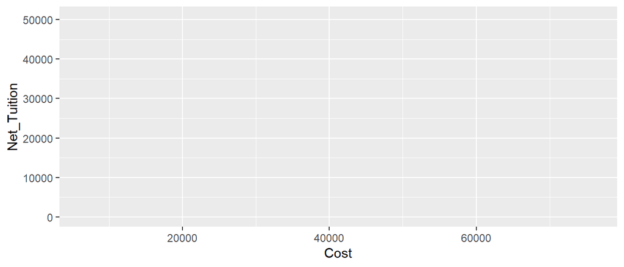

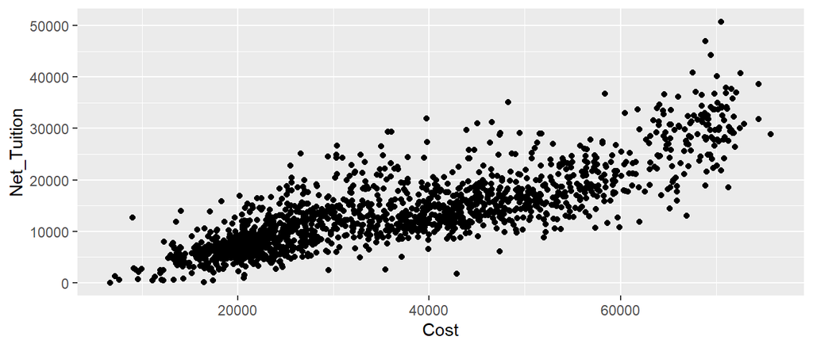

```r
## Example #1.1 - nothing (just a base layer)
ggplot(data = colleges, mapping = aes(x = Cost, y = Net_Tuition))

## Example #1.2 - add a layer displaying raw data
ggplot(data = colleges, mapping = aes(x = Cost, y = Net_Tuition)) +
  geom_point()
```

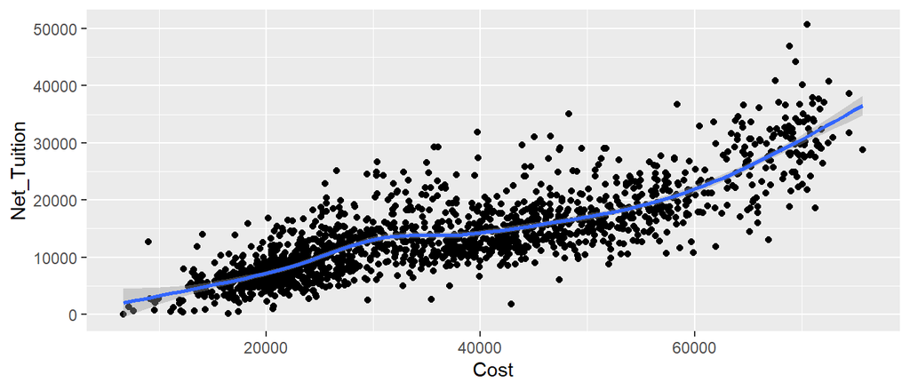

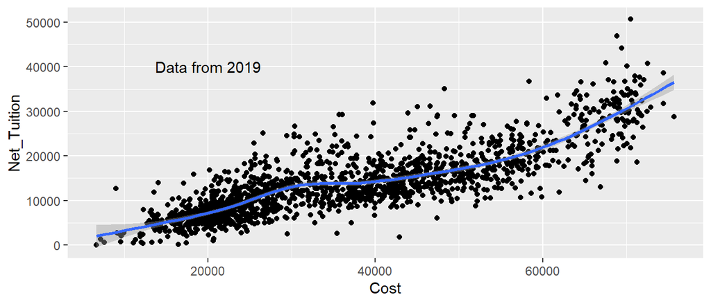

```r
## Example #1.3 - add another layer (smoother)
ggplot(data = colleges, mapping = aes(x = Cost, y = Net_Tuition)) +
  geom_point() +
  geom_smooth()

## Example #1.4 - add another layer (reference text)
ggplot(data = colleges, mapping = aes(x = Cost, y = Net_Tuition)) +
  geom_point() +
  geom_smooth() +
  annotate("text", x =20000, y=40000, label = "Data from 2019")
```

*NOTE*: A high-quality graphic doesn’t require any particular number of layers. In fact, more layers can sometimes detract from the clarity of a data visualization.

### More on the base layer

The `mapping` and `data` arguments provided in the base layer are carried forward to all subsequent layers (which is often desirable). However, we can avoid this behavior.

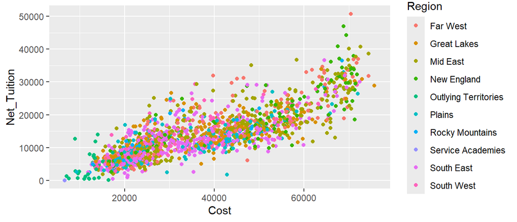

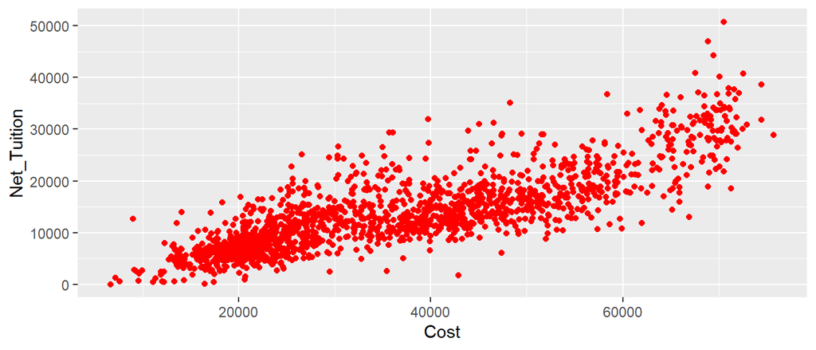

```r
## Example #2.1
ggplot(data = colleges, mapping = aes(x = Cost, y = Net_Tuition, color = Region)) +
  geom_point()

## Example #2.2 (local override of color aesthetic)
ggplot(data = colleges, mapping = aes(x = Cost, y = Net_Tuition, color = Region)) +
  geom_point(color = "red")
```

Specifying aesthetics locally within layers:

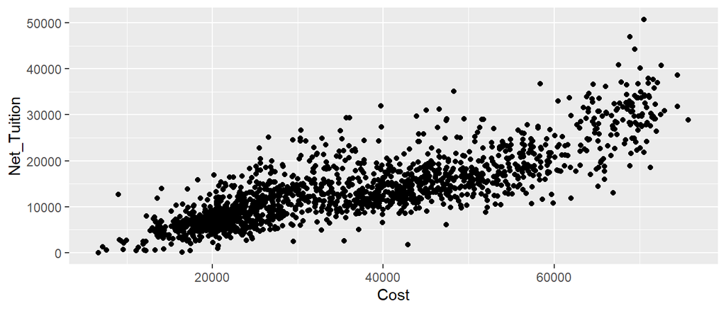

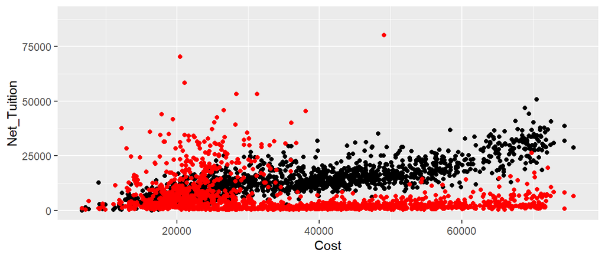

```r
## Example #3.1
ggplot(data = colleges) +
  geom_point(mapping = aes(x = Cost, y = Net_Tuition))

## Example #3.2
ggplot(data = colleges) +
  geom_point(mapping = aes(x = Cost, y = Net_Tuition)) +
  geom_point(mapping = aes(x = Cost, y = Enrollment), color = "red")
```

Local specification is most useful when you want to add layers that involve the same parameters (“x” and “y” in the example above) but for different things. Common examples are drawing a line through several different group means of an ordinal categorical variable, or displaying both polygons and points on a map.

### Terminology

The `ggplot` framework is unique because all graphics are *grammatically defined* using the following terminology:

- **Aesthetics** (or “aes”) - mappings of variables to visual cues representing their values (ie: position on the x-axis)
- **Geometric elements** (or “geom”) - what you actually see in the plot (ie: points, lines, etc.)
- **Scales** - guidelines for how aesthetic mappings should be displayed (ie: logarithmic x-axis, red to blue color palate, etc.)
- **Guides** (or “legends”) - references to help a human reader interpret the aesthetics
- **Facets** - rules specifying how to break up and separately display subsets of data

**Question #1**: Identify and briefly describe each term mentioned above in the graphic created by the code below.

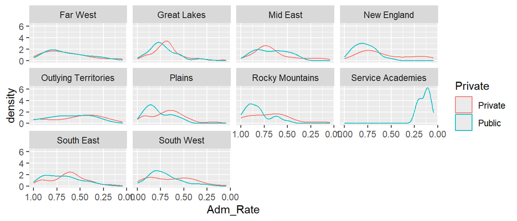

```r
ggplot(data = colleges, mapping = aes(x = Adm_Rate, color = Private)) +
  geom_density() +
  scale_x_continuous(trans = "reverse") +
  facet_wrap(~Region)
```

**Question #2**: Create a scatterplot to predict net tuition from the average faculty salary. Facet by the variable “Private”. Use the [ggplot2 cheatsheet](https://raw.githubusercontent.com/rstudio/cheatsheets/main/data-visualization.pdf) to help you identify the necessary functions and arguments.

`ggplot` graphics are a very expansive topic and not everything can be self-contained in this lab. Throughout the lab, I encourage you to reference the following resources if you need to figure out the proper function or syntax for a particular task:

- [ggplot2 cheatsheet](https://raw.githubusercontent.com/rstudio/cheatsheets/main/data-visualization.pdf)
- [ggplot2 book](https://ggplot2-book.org/)

### Themes

Themes are pre-built style templates used to better tailor a graphic to the mode of publication.

The example below applies a black and white theme to Example 2.1 from the preamble.

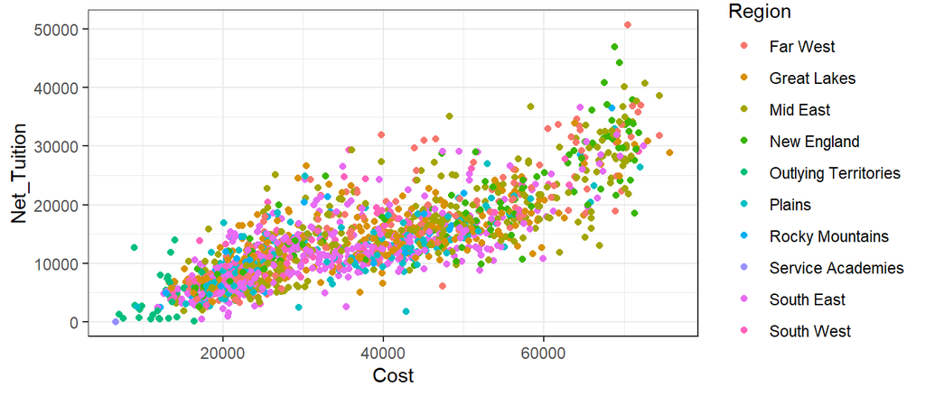

```r
## Example #2.1 w/ black and white theme
ggplot(data = colleges, mapping = aes(x = Cost, y = Net_Tuition, color = Region)) +
  geom_point() +
  theme_bw()
```

Other pre-built themes:

- `theme_bw()`
- `theme_linedraw()`, `theme_light()` and `theme_dark()`
- `theme_minimal()`
- `theme_classic()`
- `theme_void()`

You can judge the differences in these themes below:

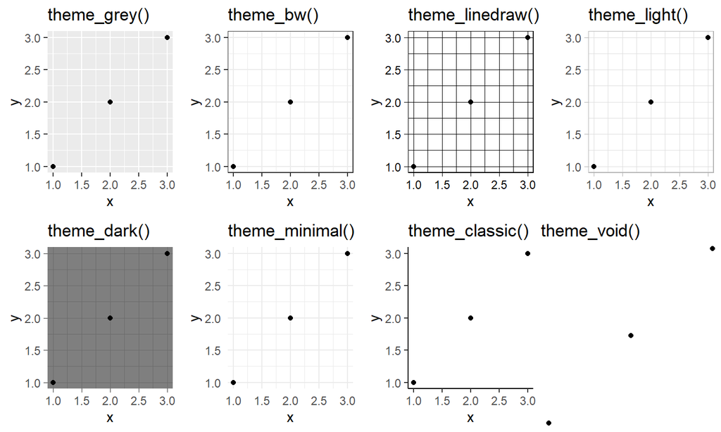

Any theme can be further customized using `theme()`. Most commonly this function is used to remove a graph’s legend:

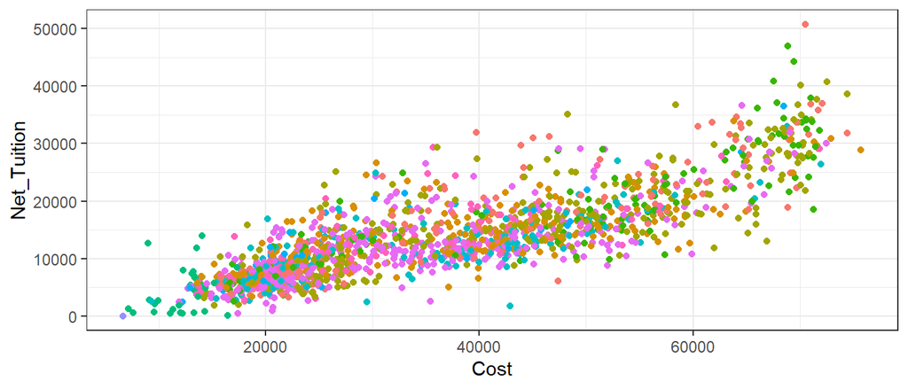

```r
## Example #2.1 w/ black and white theme
ggplot(data = colleges, mapping = aes(x = Cost, y = Net_Tuition, color = Region)) +
  geom_point() +
  theme_bw() +
  theme(legend.position = "none")
```

### Labels and Annotations

Labels and annotations are important aspects of well-constructed data visualizations. They are used to provide context, or draw the viewer’s attention towards particular aspects of the graphic.

Labels corresponding to *aesthetics* (such as `x`, `y`, `color`, etc.) are controlled using the `labs()` function:

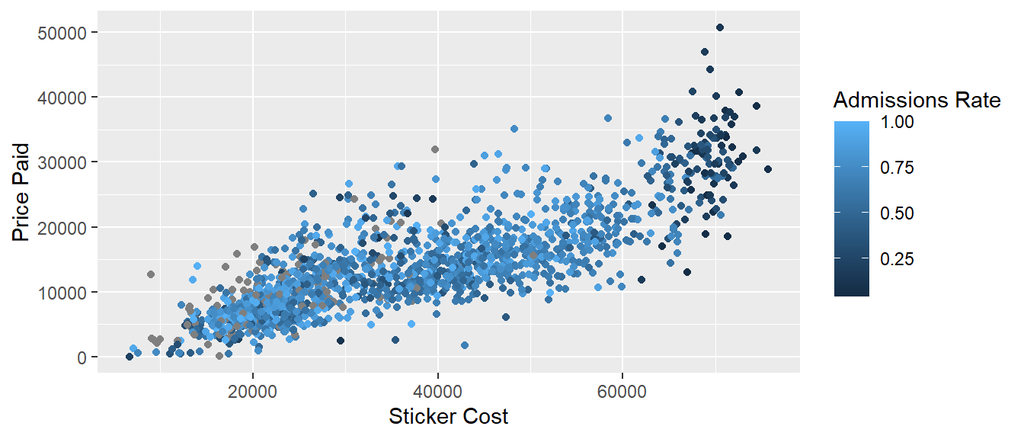

```r
ggplot(data = colleges, mapping = aes(x = Cost, y = Net_Tuition, color = Adm_Rate)) +
  geom_point() +
  labs(x = "Sticker Cost", y = "Price Paid", color = "Admissions Rate")
```

Annotations are added the graphic as a layer using the `annotate()` function:

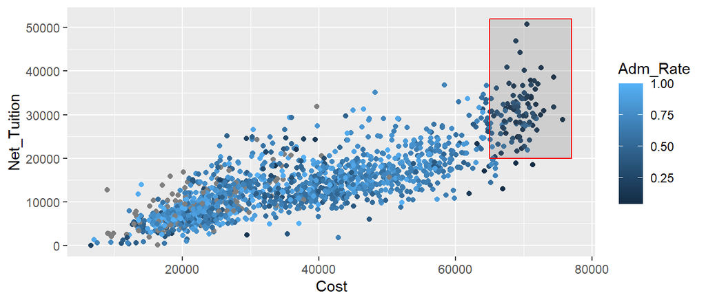

```r
ggplot(data = colleges, mapping = aes(x = Cost, y = Net_Tuition, color = Adm_Rate)) +
  geom_point() +
  annotate(geom = "rect", xmin = 65000, xmax = 77000, ymin = 20000, ymax = 52000, color = "red", alpha = 0.2)
```

**Question #3**: Use the `filter()` function from the dyplr package to create a data frame containing only colleges located in the state of Iowa. Using these data, create a side-by-side box plot of admissions rates by public and private schools. Overlay the boxplot with points representing each school. Add a text annotation beside the outlier saying “Grinnell”.

### Scales

Scales map values in the data space to the aesthetic space (ie: where and how should data with `Adm_Rate=0.2`, `Cost=40000`, and `Net_Tuition=10000` appear on the graphic?).

Scales can be modified by adding layers using functions whose names follow the general format: “scale_aesthetic_function()”. Shown below are a few examples:

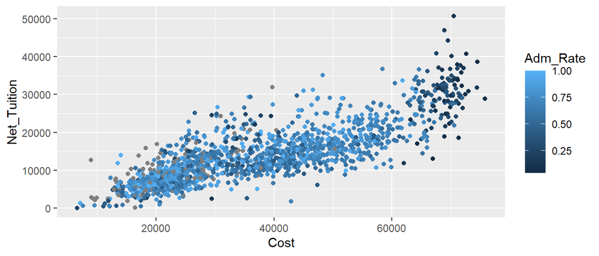

```r
## Default Scales
ggplot(data = colleges, mapping = aes(x = Cost, y = Net_Tuition, color = Adm_Rate)) +
  geom_point()
```

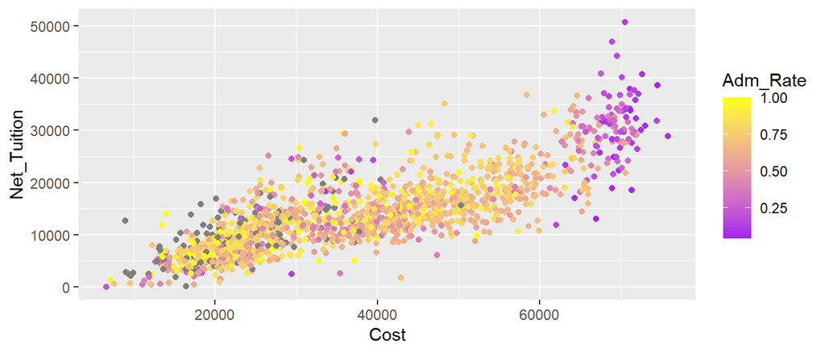

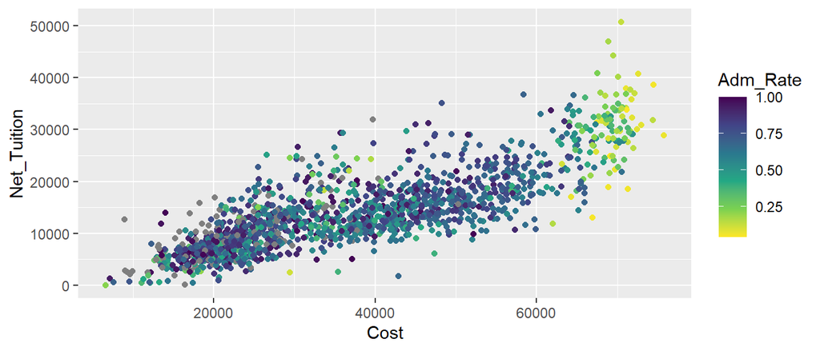

```r
## Use a gradient from purple to yellow to display Adm_Rate
ggplot(data = colleges, mapping = aes(x = Cost, y = Net_Tuition, color = Adm_Rate)) +
  geom_point() +
  scale_color_gradient(low = "purple", high = "yellow")

## Use the popular "viridis" color scale, reversing the default direction via "-1"
ggplot(data = colleges, mapping = aes(x = Cost, y = Net_Tuition, color = Adm_Rate)) +
  geom_point() +
  scale_color_continuous(type = "viridis", direction = -1)
```

There are two things you should note at this point:

1. There are variants of scale functions depending upon the type of the variable being used by that aesthetic. In these examples, `scale_color_continuous()` is used because “Adm_Rate” is a continuous numeric variable. However, if colors were being determined by a character string you’d want to use `scale_color_brewer()` instead (or one of the related color scale functions designed for discrete variables).
2. The *color aesthetic* is not synonymous with all of the color you see on the graph. For example, the `fill` aesthetic can be used to add color to a bar chart, and you must use a function like `scale_fill_brewer()` to change the fill color.

**Question #4**: Modify the code below to make the shape squares with blue outlines and red fill. Then use `alpha =.4` to reduce the transparency of the squares.

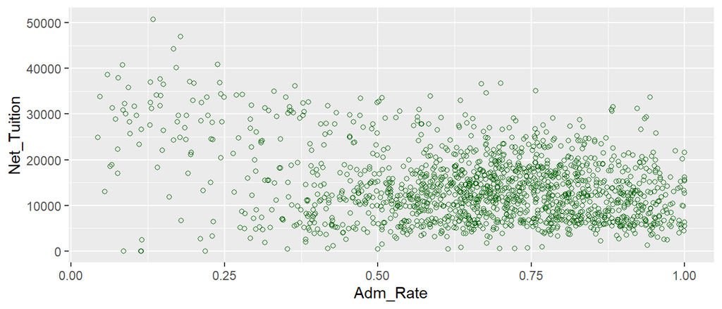

```r
ggplot(data = colleges, mapping = aes(x = Adm_Rate, y = Net_Tuition)) +
  geom_point(color = "darkgreen", shape = 1)
```

### Stats

Sometimes we’d like to display a statistical transformation (mean, error bars, etc.) alongside the data itself. While this could be accomplished by creating a separate data frame, it’s generally better to use a `stat_` function:

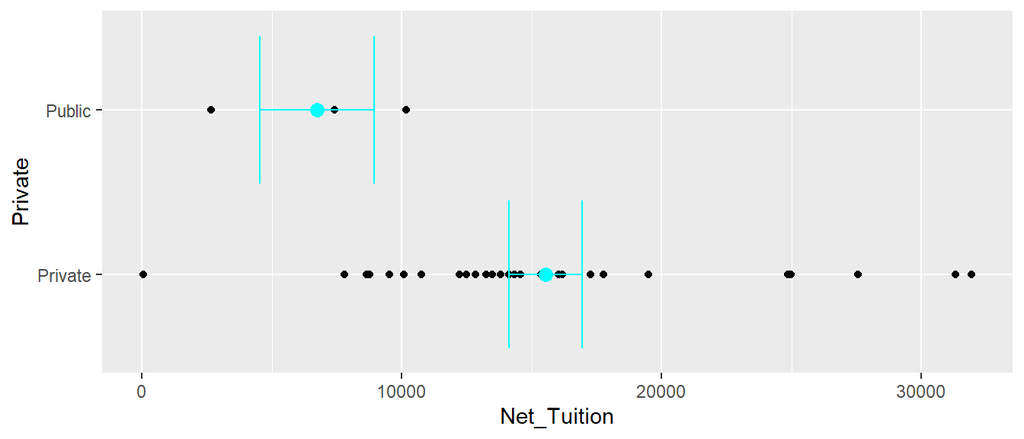

```r
ggplot(data = colleges[1:30,], mapping = aes(x = Net_Tuition, y = Private)) +
  geom_point() +
  stat_summary(fun = mean, geom = "point", color = "cyan", size = 3) +
  stat_summary(fun.data = mean_se, geom = "errorbar", color = "cyan")
```

The example above adds error bars at 1 standard error above and below the mean net tuition cost of for the private and public colleges in the first 30 rows of the `colleges` data frame.

Notice how the first instance of `stat_summary()` uses the `fun` argument (a simple option designed to return a single number/vector), while the second uses the `fun.data` argument (a complex option designed to return a data frame, which contains the lower and upper endpoints of the interval in this example).

**Question #5**: Using the data subset containing only colleges located in Iowa (created earlier), create a graph similar to the example above but using the arguments `geom = "linerange"`, `alpha = 0.3`, `size = 4`, and `color = "darkslateblue"` to depict 1 standard error above/below the means of private and public colleges.

### Facets

Relying on large numbers of aesthetics to include additional variables on a graph can quickly become overwhelming. Facets allow you to display multiple side-by-side graphs according to one or more categorical variables.

- `facet_wrap()` is designed to display the data broken by a single categorical variable
- `facet_grid()` is designed to display the data broken by all combinations of two categorical variables

Two examples of faceting are shown below:

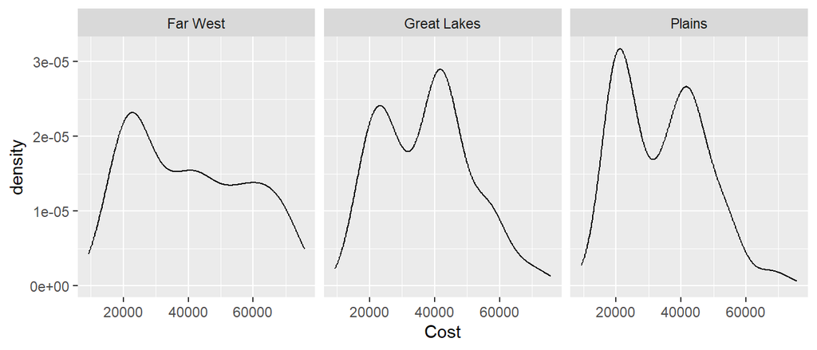

```r
## create a subset for example purposes
reduced_colleges = subset(colleges, Region %in% c("Great Lakes", "Far West", "Plains"))

## facet_wrap
ggplot(data = reduced_colleges, mapping = aes(x = Cost)) +
  geom_density() +
  facet_wrap(~Region, nrow = 1)
```

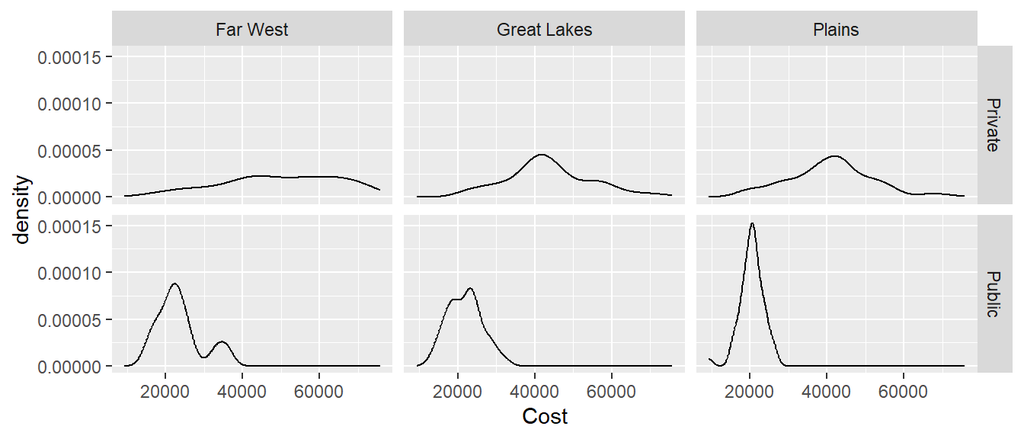

```r
## facet_grid
ggplot(data = reduced_colleges, mapping = aes(x = Cost)) +
  geom_density() +
  facet_grid(Private~Region)
```

The `facet_wrap()` function will wrap a series of plots according to a fixed number of rows or columns, while `facet_grid()` will construct a 2-dimensional grid whose panels correspond to the unique combinations of values in the variables used in the grid formula.

**Question #6**: Read in the Ames housing data from https://grinnell-statistics.github.io/Grinnell_R_Tutorials/data/AmesHousing.csv . Create a graphic that shows the relationship between the outcome variable “SalePrice” and the explanatory variables: “YearBuilt”. Color by the number of rooms above ground and facet by quality of the kitchen. Add a simple linear regression line. Use the black white theme. Give the graph a title and clear labels.

**Practice**: